# Project1 ST558

Matthew Sookoo

2022-09-12

# Overall Goal

The purpose of this project is to write functions that will manipulate and process data sets that come in a certain form. Also we create a generic function to automatically plot the returned data.

# Data Processing

We begin by reading in one section of the data given and load tidyverse. Dplyr is part of the tidyverse.

```r
library(tidyverse)
sheet1 <- read_csv("https://www4.stat.ncsu.edu/~online/datasets/EDU01a.csv")
```

We continue with the following six steps.

## Step 1

Firstly we rename Area_name to area_name and save the data set as an object called sheet1renamed.

```r
sheet1renamed<-rename(sheet1, area_name = Area_name)
```

Next we select (subset the columns) the desired columns area_name, STCOU and columns that end with the letter D using the chain below.

```r
sheet1renamed%>%
  select(area_name, STCOU, ends_with("D"))
```

```
## # A tibble: 3,198 × 12
##    area_…¹ STCOU EDU01…² EDU01…³ EDU01…⁴ EDU01…⁵ EDU01…⁶ EDU01…⁷ EDU01…⁸ EDU01…⁹
##    <chr>   <chr>   <dbl>   <dbl>   <dbl>   <dbl>   <dbl>   <dbl>   <dbl>   <dbl>
##  1 UNITED… 00000  4.00e7  4.00e7  4.03e7  4.07e7  4.14e7  4.21e7  4.27e7  4.34e7
##  2 ALABAMA 01000  7.34e5  7.28e5  7.30e5  7.28e5  7.26e5  7.26e5  7.28e5  7.31e5
##  3 Autaug… 01001  6.83e3  6.9 e3  6.92e3  6.85e3  7.01e3  7.14e3  7.15e3  7.38e3
##  4 Baldwi… 01003  1.64e4  1.65e4  1.68e4  1.71e4  1.75e4  1.80e4  1.87e4  1.94e4
##  5 Barbou… 01005  5.07e3  5.10e3  5.07e3  5.16e3  5.17e3  5.25e3  5.14e3  5.11e3
##  6 Bibb, … 01007  3.56e3  3.51e3  3.57e3  3.62e3  3.65e3  3.56e3  3.56e3  3.55e3
##  7 Blount… 01009  7.32e3  7.22e3  7.20e3  7.21e3  7.16e3  7.15e3  7.21e3  7.3 e3
##  8 Bulloc… 01011  2.01e3  1.98e3  1.98e3  1.98e3  1.98e3  2.02e3  2.01e3  2.01e3
##  9 Butler… 01013  4.64e3  4.58e3  4.61e3  4.59e3  4.54e3  4.48e3  4.44e3  4.35e3
## 10 Calhou… 01015  2.09e4  2.09e4  2.09e4  2.08e4  2.08e4  2.05e4  2.05e4  2.01e4
## # … with 3,188 more rows, 2 more variables: EDU010195D <dbl>, EDU010196D <dbl>,
## #   and abbreviated variable names ¹area_name, ²EDU010187D, ³EDU010188D,
## #   ⁴EDU010189D, ⁵EDU010190D, ⁶EDU010191D, ⁷EDU010192D, ⁸EDU010193D,
## #   ⁹EDU010194D
```

## Step 2

Continuing the chain from Step 1 we convert to long format. This is achieved by using `pivot_longer()`.

```r
sheet1renamed%>%

  select(area_name, STCOU, ends_with("D"))%>%

  pivot_longer(cols = 3:12, names_to = "ends_with_D", values_to = "enrollment_value")
```

```
## # A tibble: 31,980 × 4
##    area_name     STCOU ends_with_D enrollment_value
##    <chr>         <chr> <chr>                  <dbl>
##  1 UNITED STATES 00000 EDU010187D          40024299
##  2 UNITED STATES 00000 EDU010188D          39967624
##  3 UNITED STATES 00000 EDU010189D          40317775
##  4 UNITED STATES 00000 EDU010190D          40737600
##  5 UNITED STATES 00000 EDU010191D          41385442
##  6 UNITED STATES 00000 EDU010192D          42088151
##  7 UNITED STATES 00000 EDU010193D          42724710
##  8 UNITED STATES 00000 EDU010194D          43369917
##  9 UNITED STATES 00000 EDU010195D          43993459
## 10 UNITED STATES 00000 EDU010196D          44715737
## # … with 31,970 more rows
```

## Step 3

Continuing the chain from Step 2, we Parse the string to pull out the year and convert the year into a numeric. This gives the two digit date as a column which we name “year2digit”. In order to do this we use the `substr()` and `as.numeric()` to convert to a numeric value

```r
sheet1renamed%>%

  select(area_name, STCOU, ends_with("D"))%>%

  pivot_longer(cols = 3:12, names_to = "ends_with_D", values_to = "enrollment_value")%>%

  mutate(year2digit = as.numeric(substr(as.character(ends_with_D),8,9)))
```

```
## # A tibble: 31,980 × 5
##    area_name     STCOU ends_with_D enrollment_value year2digit
##    <chr>         <chr> <chr>                  <dbl>      <dbl>
##  1 UNITED STATES 00000 EDU010187D          40024299         87
##  2 UNITED STATES 00000 EDU010188D          39967624         88
##  3 UNITED STATES 00000 EDU010189D          40317775         89
##  4 UNITED STATES 00000 EDU010190D          40737600         90
##  5 UNITED STATES 00000 EDU010191D          41385442         91
##  6 UNITED STATES 00000 EDU010192D          42088151         92
##  7 UNITED STATES 00000 EDU010193D          42724710         93
##  8 UNITED STATES 00000 EDU010194D          43369917         94
##  9 UNITED STATES 00000 EDU010195D          43993459         95
## 10 UNITED STATES 00000 EDU010196D          44715737         96
## # … with 31,970 more rows
```

Continuing the chain from abover, since we want the 4 digit date we create a new column called “year” using `mutate()` and we take all the two digits from “year2digit” that are greater than or equal to 70 and add 1900 otherwise we add 2000, so for example 82 becomes 1982 and 02 becomes 2002.

We use 70 because 71 was the lowest two digit year for all the data we wish to use in this project.

```r
sheet1renamed%>%

  select(area_name, STCOU, ends_with("D"))%>%

  pivot_longer(cols = 3:12, names_to = "ends_with_D", values_to = "enrollment_value")%>%

  mutate(year2digit = as.numeric(substr(as.character(ends_with_D),8,9)))%>%

  mutate(year=if_else(year2digit>=70,year2digit+1900,year2digit+2000))
```

```
## # A tibble: 31,980 × 6
##    area_name     STCOU ends_with_D enrollment_value year2digit  year
##    <chr>         <chr> <chr>                  <dbl>      <dbl> <dbl>
##  1 UNITED STATES 00000 EDU010187D          40024299         87  1987
##  2 UNITED STATES 00000 EDU010188D          39967624         88  1988
##  3 UNITED STATES 00000 EDU010189D          40317775         89  1989
##  4 UNITED STATES 00000 EDU010190D          40737600         90  1990
##  5 UNITED STATES 00000 EDU010191D          41385442         91  1991
##  6 UNITED STATES 00000 EDU010192D          42088151         92  1992
##  7 UNITED STATES 00000 EDU010193D          42724710         93  1993
##  8 UNITED STATES 00000 EDU010194D          43369917         94  1994
##  9 UNITED STATES 00000 EDU010195D          43993459         95  1995
## 10 UNITED STATES 00000 EDU010196D          44715737         96  1996
## # … with 31,970 more rows
```

Continuing the chain from above, now that we have created the column with the four digit year, we delete the unwanted column “year2digit” using select(-year2digit).

```r
sheet1renamed%>%

  select(area_name, STCOU, ends_with("D"))%>%

  pivot_longer(cols = 3:12, names_to = "ends_with_D", values_to = "enrollment_value")%>%

  mutate(year2digit = as.numeric(substr(as.character(ends_with_D),8,9)))%>%

  mutate(year=if_else(year2digit>=70,year2digit+1900,year2digit+2000))%>%

  select(-year2digit)
```

```
## # A tibble: 31,980 × 5
##    area_name     STCOU ends_with_D enrollment_value  year
##    <chr>         <chr> <chr>                  <dbl> <dbl>
##  1 UNITED STATES 00000 EDU010187D          40024299  1987
##  2 UNITED STATES 00000 EDU010188D          39967624  1988
##  3 UNITED STATES 00000 EDU010189D          40317775  1989
##  4 UNITED STATES 00000 EDU010190D          40737600  1990
##  5 UNITED STATES 00000 EDU010191D          41385442  1991
##  6 UNITED STATES 00000 EDU010192D          42088151  1992
##  7 UNITED STATES 00000 EDU010193D          42724710  1993
##  8 UNITED STATES 00000 EDU010194D          43369917  1994
##  9 UNITED STATES 00000 EDU010195D          43993459  1995
## 10 UNITED STATES 00000 EDU010196D          44715737  1996
## # … with 31,970 more rows
```

Proceeding with the chain above, We take the first three characters and following four digits to create a new variable called “survey_type” and we save as an object called “to_split”.

```r
sheet1renamed%>%

  select(area_name, STCOU, ends_with("D"))%>%

  pivot_longer(cols = 3:12, names_to = "ends_with_D", values_to = "enrollment_value")%>%

  mutate(year2digit = as.numeric(substr(as.character(ends_with_D),8,9)))%>%

  mutate(year=if_else(year2digit>=70,year2digit+1900,year2digit+2000))%>%

  select(-year2digit)%>%

  mutate(survey_type = (substr(as.character(ends_with_D),1,7))) -> to_split
```

## Step 4

We use our object “to_split” and create two data sets “non_county_data” and “county_data”. We note that the county name contains “DD” where “DD” represents the state.

Using this information together with `grepl()` we successfully create the two data sets.

Alternatively we could use the grep with an if/else but after doing some reading on the internet I found that `grepl()` already returns TRUE/FALSE so there is no need for the if/else statement.

We get the county data using `grepl(pattern = ", \\w\\w", area_name)` and the non-county by using `!grepl(pattern = ", \\w\\w", area_name)`. The “, \w\w” accounts for the comma and the two letters “DD” that represent county name.

```r
  non_county_data <- filter(to_split, !grepl(pattern = ", \\w\\w", area_name))

  non_county_data
```

```
## # A tibble: 530 × 6
##    area_name     STCOU ends_with_D enrollment_value  year survey_type
##    <chr>         <chr> <chr>                  <dbl> <dbl> <chr>
##  1 UNITED STATES 00000 EDU010187D          40024299  1987 EDU0101
##  2 UNITED STATES 00000 EDU010188D          39967624  1988 EDU0101
##  3 UNITED STATES 00000 EDU010189D          40317775  1989 EDU0101
##  4 UNITED STATES 00000 EDU010190D          40737600  1990 EDU0101
##  5 UNITED STATES 00000 EDU010191D          41385442  1991 EDU0101
##  6 UNITED STATES 00000 EDU010192D          42088151  1992 EDU0101
##  7 UNITED STATES 00000 EDU010193D          42724710  1993 EDU0101
##  8 UNITED STATES 00000 EDU010194D          43369917  1994 EDU0101
##  9 UNITED STATES 00000 EDU010195D          43993459  1995 EDU0101
## 10 UNITED STATES 00000 EDU010196D          44715737  1996 EDU0101
## # … with 520 more rows
```

```r
  county_data <- filter(to_split, grepl(pattern = ", \\w\\w", area_name))

  county_data
```

```
## # A tibble: 31,450 × 6
##    area_name   STCOU ends_with_D enrollment_value  year survey_type
##    <chr>       <chr> <chr>                  <dbl> <dbl> <chr>
##  1 Autauga, AL 01001 EDU010187D              6829  1987 EDU0101
##  2 Autauga, AL 01001 EDU010188D              6900  1988 EDU0101
##  3 Autauga, AL 01001 EDU010189D              6920  1989 EDU0101
##  4 Autauga, AL 01001 EDU010190D              6847  1990 EDU0101
##  5 Autauga, AL 01001 EDU010191D              7008  1991 EDU0101
##  6 Autauga, AL 01001 EDU010192D              7137  1992 EDU0101
##  7 Autauga, AL 01001 EDU010193D              7152  1993 EDU0101
##  8 Autauga, AL 01001 EDU010194D              7381  1994 EDU0101
##  9 Autauga, AL 01001 EDU010195D              7568  1995 EDU0101
## 10 Autauga, AL 01001 EDU010196D              7834  1996 EDU0101
## # … with 31,440 more rows
```

Next we add a class to the county tibble called county

```r
class(county_data) <- c("county", class(county_data))
```

Similarly, we add a class to the non_county tibble called state

```r
class(non_county_data) <- c("state", class(non_county_data))
```

we run `class(county_data)` or `str(county_data)` to confirm the new class was added. Similarly we do the same for the non_county_data.

```r
 class(county_data)
```

```
## [1] "county"     "tbl_df"     "tbl"        "data.frame"
```

```r
 class(non_county_data)
```

```
## [1] "state"      "tbl_df"     "tbl"        "data.frame"
```

## Step5

We create a new variable using `mutate()`. We call this new variable “county_state”. “county_state” describes which state the county belongs using the two digit abbreviation “DD” mentioned earlier. We take the last string with these two digit abbreviation using nchar(area_name)-1, nchar(area_name) inside the `substr()` function.

```r
county_data %>% mutate(county_state = substr(as.character(area_name),nchar(area_name)-1,
                                             nchar(area_name)))
```

```
## # A tibble: 31,450 × 7
##    area_name   STCOU ends_with_D enrollment_value  year survey_type county_state
##    <chr>       <chr> <chr>                  <dbl> <dbl> <chr>       <chr>
##  1 Autauga, AL 01001 EDU010187D              6829  1987 EDU0101     AL
##  2 Autauga, AL 01001 EDU010188D              6900  1988 EDU0101     AL
##  3 Autauga, AL 01001 EDU010189D              6920  1989 EDU0101     AL
##  4 Autauga, AL 01001 EDU010190D              6847  1990 EDU0101     AL
##  5 Autauga, AL 01001 EDU010191D              7008  1991 EDU0101     AL
##  6 Autauga, AL 01001 EDU010192D              7137  1992 EDU0101     AL
##  7 Autauga, AL 01001 EDU010193D              7152  1993 EDU0101     AL
##  8 Autauga, AL 01001 EDU010194D              7381  1994 EDU0101     AL
##  9 Autauga, AL 01001 EDU010195D              7568  1995 EDU0101     AL
## 10 Autauga, AL 01001 EDU010196D              7834  1996 EDU0101     AL
## # … with 31,440 more rows
```

## Step 6

```r
Division1 <- c("Connecticut", "Maine", "Massachusetts", "New Hampshire", "Rhode Island",
               "Vermont")

Division1<-toupper(Division1)

Division2 <- c("New Jersey", "New York", "Pennsylvania")

Division2<-toupper(Division2)

Division3 <- c("Illinois", "Indiana", "Michigan", "Ohio", "Wisconsin")

Division3<-toupper(Division3)

Division4 <- c("Iowa", "Kansas", "Minnesota", "Missouri", "Nebraska", "North Dakota",
               "South Dakota")

Division4<-toupper(Division4)

Division5 <- c("Delaware", "Florida", "Georgia", "Maryland", "North Carolina",
               "South Carolina", "Virginia", "Washington, D.C.", "West Virginia")

#Washington, D.C.was not in the data given. I noticed it had District of Columbia. This would return error. If you want to get District of Columbia to show Division5 we just simply include "District of Columbia" (capital letters and common letters) in Division5 object above

Division5<-toupper(Division5)

Division6 <- c("Alabama", "Kentucky", "Mississippi", "Tennessee")

Division6<-toupper(Division6)

Division7 <- c("Arkansas", "Louisiana", "Oklahoma", "Texas")

Division7<-toupper(Division7)

Division8 <- c("Arizona", "Colorado", "Idaho", "Montana", "Nevada", "New Mexico", "Utah",
               "Wyoming")

Division8<-toupper(Division8)

Division9 <- c("Alaska", "California", "Hawaii", "Oregon", "Washington")

Division9<-toupper(Division9)
```

We now use an if_else statement in the `mutate()` function to create the new required variable which we call “division”. We achieve this using chaining.

```r
non_county_data %>%

  mutate(division = if_else(area_name %in% Division1, "Division1",
                                      if_else(area_name %in% Division2, "Division2",
                                      if_else(area_name %in% Division3, "Division3",
                                      if_else(area_name %in% Division4, "Division4",
                                      if_else(area_name %in% Division5, "Division5",
                                      if_else(area_name %in% Division6, "Division6",
                                      if_else(area_name %in% Division7, "Division7",
                                      if_else(area_name %in% Division8, "Division8",
                                      if_else(area_name %in% Division9, "Division9",
                                              "ERROR"))))))))))
```

```
## # A tibble: 530 × 7
##    area_name     STCOU ends_with_D enrollment_value  year survey_type division
##    <chr>         <chr> <chr>                  <dbl> <dbl> <chr>       <chr>
##  1 UNITED STATES 00000 EDU010187D          40024299  1987 EDU0101     ERROR
##  2 UNITED STATES 00000 EDU010188D          39967624  1988 EDU0101     ERROR
##  3 UNITED STATES 00000 EDU010189D          40317775  1989 EDU0101     ERROR
##  4 UNITED STATES 00000 EDU010190D          40737600  1990 EDU0101     ERROR
##  5 UNITED STATES 00000 EDU010191D          41385442  1991 EDU0101     ERROR
##  6 UNITED STATES 00000 EDU010192D          42088151  1992 EDU0101     ERROR
##  7 UNITED STATES 00000 EDU010193D          42724710  1993 EDU0101     ERROR
##  8 UNITED STATES 00000 EDU010194D          43369917  1994 EDU0101     ERROR
##  9 UNITED STATES 00000 EDU010195D          43993459  1995 EDU0101     ERROR
## 10 UNITED STATES 00000 EDU010196D          44715737  1996 EDU0101     ERROR
## # … with 520 more rows
```

# Requirements

In this section we want to repeat the above process for the 2nd component of the data set. Instead of copying and pasting the above code and modifying, we want to write functions that do the above six Steps and one function that we can call to do all six steps.

## Read in code

Firstly, we read in the code in a similar manner as we did before.

```r
sheet1 <- read_csv("https://www4.stat.ncsu.edu/~online/datasets/EDU01b.csv")
```

## Function for Steps 1 and 2

We now create a function for steps 1 and 2. We use csv for the input and var_name = “enrollment_value” for the optional default argument value. We use the method similar to Step 1 and Step 2 as detailed in the “Data Processing” section to rename, select and pivot.

```r
function_for_step_1_2 <- function(csv, var_name ="enrollment_value"){
  rename <- rename(csv, area_name = Area_name) #this changes Area_name to area_name

  select <- select(rename, area_name, STCOU, ends_with("D")) #this selects the required columns

  pivot <- pivot_longer(select, cols = 3:12, names_to = "ends_with_D", values_to =
                 "enrollment_value") #this converts to long format


  return(pivot)
}


step2_output<-function_for_step_1_2(sheet1)
step2_output
```

```
## # A tibble: 31,980 × 4
##    area_name     STCOU ends_with_D enrollment_value
##    <chr>         <chr> <chr>                  <dbl>
##  1 UNITED STATES 00000 EDU010197D          44534459
##  2 UNITED STATES 00000 EDU010198D          46245814
##  3 UNITED STATES 00000 EDU010199D          46368903
##  4 UNITED STATES 00000 EDU010200D          46818690
##  5 UNITED STATES 00000 EDU010201D          47127066
##  6 UNITED STATES 00000 EDU010202D          47606570
##  7 UNITED STATES 00000 EDU015203D          48506317
##  8 UNITED STATES 00000 EDU015204D          48693287
##  9 UNITED STATES 00000 EDU015205D          48978555
## 10 UNITED STATES 00000 EDU015206D          49140702
## # … with 31,970 more rows
```

## Function taking output of Step 2 to do step 3

Next we create a function that takes in the output of step 2 outputs the desired tibble with a four digit numeric column and a new column “survey_type”.

To achieve this, in a similar manner to step 3 we create a new column called “year2digit” and convert it to a numeric value using `as.numeric`.

Using the “year2digit” column we create the required four digit column and delete the unwanted “year2digit” column.

Finally, we add a new column “survey_type” using the `mutate()` function

```r
function_for_step_3 <- function(step2_output){
   yr_2digit<-mutate(step2_output, year2digit =
                      as.numeric(substr(as.character(ends_with_D),8,9)))
  yr_4digit<-mutate(yr_2digit,
                     year=if_else(year2digit>=70,year2digit+1900,year2digit+2000))

  delete_2digit_col<-select(yr_4digit, -year2digit)

  col_survey_type<-mutate(delete_2digit_col, survey_type =
                            (substr(as.character(ends_with_D),1,7)))

  return(col_survey_type)
}

step3_output <- function_for_step_3(step2_output)

step3_output
```

```
## # A tibble: 31,980 × 6
##    area_name     STCOU ends_with_D enrollment_value  year survey_type
##    <chr>         <chr> <chr>                  <dbl> <dbl> <chr>
##  1 UNITED STATES 00000 EDU010197D          44534459  1997 EDU0101
##  2 UNITED STATES 00000 EDU010198D          46245814  1998 EDU0101
##  3 UNITED STATES 00000 EDU010199D          46368903  1999 EDU0101
##  4 UNITED STATES 00000 EDU010200D          46818690  2000 EDU0102
##  5 UNITED STATES 00000 EDU010201D          47127066  2001 EDU0102
##  6 UNITED STATES 00000 EDU010202D          47606570  2002 EDU0102
##  7 UNITED STATES 00000 EDU015203D          48506317  2003 EDU0152
##  8 UNITED STATES 00000 EDU015204D          48693287  2004 EDU0152
##  9 UNITED STATES 00000 EDU015205D          48978555  2005 EDU0152
## 10 UNITED STATES 00000 EDU015206D          49140702  2006 EDU0152
## # … with 31,970 more rows
```

## Function for Step 5

We now write a function to do step 5 as follows. This function takes in a data frame and creates a new variable which we name “county_state”. We achieve this using both the `mutate()` and `substr()` functions in a similar way as described in the “Data Processing” section.

```r
function_for_step_5<-function(df){

  step_5_fn <- mutate(df, county_state = substr(as.character(area_name),nchar(area_name)-1,
                                             nchar(area_name)))
  return(step_5_fn)
}
```

## Function for Step 6

```r
function_for_step_6<-function(df){

  Division1 <- c("Connecticut", "Maine", "Massachusetts", "New Hampshire", "Rhode
                 Island", "Vermont")

Division1<-toupper(Division1)

Division2 <- c("New Jersey", "New York", "Pennsylvania")

Division2<-toupper(Division2)

Division3 <- c("Illinois", "Indiana", "Michigan", "Ohio", "Wisconsin")

Division3<-toupper(Division3)

Division4 <- c("Iowa", "Kansas", "Minnesota", "Missouri", "Nebraska", "North Dakota",
               "South Dakota")

Division4<-toupper(Division4)

Division5 <- c("Delaware", "Florida", "Georgia", "Maryland", "North Carolina",
               "South Carolina", "Virginia", "Washington, D.C.", "West Virginia")

#Washington, D.C.was not in the data given. I noticed it had District of Columbia. This would return error. If you want to get District of Columbia to show Division5 we just simply include "District of Columbia" in Division5 object above

Division5<-toupper(Division5)

Division6 <- c("Alabama", "Kentucky", "Mississippi", "Tennessee")

Division6<-toupper(Division6)

Division7 <- c("Arkansas", "Louisiana", "Oklahoma", "Texas")

Division7<-toupper(Division7)

Division8 <- c("Arizona", "Colorado", "Idaho", "Montana", "Nevada", "New Mexico", "Utah",
               "Wyoming")

Division8<-toupper(Division8)

Division9 <- c("Alaska", "California", "Hawaii", "Oregon", "Washington")

Division9<-toupper(Division9)

step_6_fn<-mutate(df, division = if_else(area_name %in% Division1, "Division1",
                                      if_else(area_name %in% Division2, "Division2",
                                      if_else(area_name %in% Division3, "Division3",
                                      if_else(area_name %in% Division4, "Division4",
                                      if_else(area_name %in% Division5, "Division5",
                                      if_else(area_name %in% Division6, "Division6",
                                      if_else(area_name %in% Division7, "Division7",
                                      if_else(area_name %in% Division8, "Division8",
                                      if_else(area_name %in% Division9, "Division9",
                                              "ERROR"))))))))))

return(step_6_fn)
}
```

## Function for Steps 4, 5 and 6

We now next write a function to output the two tibbles for the non-county data and county data we also add a class to each tibble. This function takes in the output of Step 3 and outputs a list containing the two tibbles for the county data and the non-county data

```r
function_for_step_4_5_6<-function(step3_output){
  non_county_data <- filter(step3_output, !grepl(pattern = ", \\w\\w", area_name))

  # we add a class to the non_county tibble called state
 class(non_county_data) <- c("state", class(non_county_data))

 county_data <- filter(step3_output, grepl(pattern = ", \\w\\w", area_name))

  #we add a class to the county tibble called county
 class(county_data) <- c("county", class(county_data))



 county_tibble<-function_for_step_5(county_data)

 non_county_tibble<-function_for_step_6(non_county_data)

  return(list(CountyData=county_tibble, NonCountyData=non_county_tibble))
}

function_for_step_4_5_6(step3_output)
```

```
## $CountyData
## # A tibble: 31,450 × 7
##    area_name   STCOU ends_with_D enrollment_value  year survey_type county_state
##    <chr>       <chr> <chr>                  <dbl> <dbl> <chr>       <chr>
##  1 Autauga, AL 01001 EDU010197D              8099  1997 EDU0101     AL
##  2 Autauga, AL 01001 EDU010198D              8211  1998 EDU0101     AL
##  3 Autauga, AL 01001 EDU010199D              8489  1999 EDU0101     AL
##  4 Autauga, AL 01001 EDU010200D              8912  2000 EDU0102     AL
##  5 Autauga, AL 01001 EDU010201D              8626  2001 EDU0102     AL
##  6 Autauga, AL 01001 EDU010202D              8762  2002 EDU0102     AL
##  7 Autauga, AL 01001 EDU015203D              9105  2003 EDU0152     AL
##  8 Autauga, AL 01001 EDU015204D              9200  2004 EDU0152     AL
##  9 Autauga, AL 01001 EDU015205D              9559  2005 EDU0152     AL
## 10 Autauga, AL 01001 EDU015206D              9652  2006 EDU0152     AL
## # … with 31,440 more rows
##
## $NonCountyData
## # A tibble: 530 × 7
##    area_name     STCOU ends_with_D enrollment_value  year survey_type division
##    <chr>         <chr> <chr>                  <dbl> <dbl> <chr>       <chr>
##  1 UNITED STATES 00000 EDU010197D          44534459  1997 EDU0101     ERROR
##  2 UNITED STATES 00000 EDU010198D          46245814  1998 EDU0101     ERROR
##  3 UNITED STATES 00000 EDU010199D          46368903  1999 EDU0101     ERROR
##  4 UNITED STATES 00000 EDU010200D          46818690  2000 EDU0102     ERROR
##  5 UNITED STATES 00000 EDU010201D          47127066  2001 EDU0102     ERROR
##  6 UNITED STATES 00000 EDU010202D          47606570  2002 EDU0102     ERROR
##  7 UNITED STATES 00000 EDU015203D          48506317  2003 EDU0152     ERROR
##  8 UNITED STATES 00000 EDU015204D          48693287  2004 EDU0152     ERROR
##  9 UNITED STATES 00000 EDU015205D          48978555  2005 EDU0152     ERROR
## 10 UNITED STATES 00000 EDU015206D          49140702  2006 EDU0152     ERROR
## # … with 520 more rows
```

## Data processing wrapper Function

Finally we create a wrapper function. This function takes in the URL of a .csv file and the optional argument for the variable name.

We also calls the functions for Step 1 to Step 6 written above, and returns the two tibbles.

```r
my_wrapper <- function(url, var_name="enrollment_value"){
  a <- read_csv(url)
  b <- function_for_step_1_2(a)
  c <- function_for_step_3(b)
  d <- function_for_step_4_5_6(c)

  return(d)
}
```

# Call It and Combine Your Data

In this section we call the data processing wrapper function twice to read in and parse the two .csv files

“https://www4.stat.ncsu.edu/~online/datasets/EDU01a.csv”

“https://www4.stat.ncsu.edu/~online/datasets/EDU01b.csv”

## Calling wrapper function twice

```r
wrapper_call_1<-my_wrapper("https://www4.stat.ncsu.edu/~online/datasets/EDU01a.csv")

wrapper_call_1
```

```
## $CountyData
## # A tibble: 31,450 × 7
##    area_name   STCOU ends_with_D enrollment_value  year survey_type county_state
##    <chr>       <chr> <chr>                  <dbl> <dbl> <chr>       <chr>
##  1 Autauga, AL 01001 EDU010187D              6829  1987 EDU0101     AL
##  2 Autauga, AL 01001 EDU010188D              6900  1988 EDU0101     AL
##  3 Autauga, AL 01001 EDU010189D              6920  1989 EDU0101     AL
##  4 Autauga, AL 01001 EDU010190D              6847  1990 EDU0101     AL
##  5 Autauga, AL 01001 EDU010191D              7008  1991 EDU0101     AL
##  6 Autauga, AL 01001 EDU010192D              7137  1992 EDU0101     AL
##  7 Autauga, AL 01001 EDU010193D              7152  1993 EDU0101     AL
##  8 Autauga, AL 01001 EDU010194D              7381  1994 EDU0101     AL
##  9 Autauga, AL 01001 EDU010195D              7568  1995 EDU0101     AL
## 10 Autauga, AL 01001 EDU010196D              7834  1996 EDU0101     AL
## # … with 31,440 more rows
##
## $NonCountyData
## # A tibble: 530 × 7
##    area_name     STCOU ends_with_D enrollment_value  year survey_type division
##    <chr>         <chr> <chr>                  <dbl> <dbl> <chr>       <chr>
##  1 UNITED STATES 00000 EDU010187D          40024299  1987 EDU0101     ERROR
##  2 UNITED STATES 00000 EDU010188D          39967624  1988 EDU0101     ERROR
##  3 UNITED STATES 00000 EDU010189D          40317775  1989 EDU0101     ERROR
##  4 UNITED STATES 00000 EDU010190D          40737600  1990 EDU0101     ERROR
##  5 UNITED STATES 00000 EDU010191D          41385442  1991 EDU0101     ERROR
##  6 UNITED STATES 00000 EDU010192D          42088151  1992 EDU0101     ERROR
##  7 UNITED STATES 00000 EDU010193D          42724710  1993 EDU0101     ERROR
##  8 UNITED STATES 00000 EDU010194D          43369917  1994 EDU0101     ERROR
##  9 UNITED STATES 00000 EDU010195D          43993459  1995 EDU0101     ERROR
## 10 UNITED STATES 00000 EDU010196D          44715737  1996 EDU0101     ERROR
## # … with 520 more rows
```

```r
wrapper_call_2<-my_wrapper("https://www4.stat.ncsu.edu/~online/datasets/EDU01b.csv")

wrapper_call_2
```

```
## $CountyData
## # A tibble: 31,450 × 7
##    area_name   STCOU ends_with_D enrollment_value  year survey_type county_state
##    <chr>       <chr> <chr>                  <dbl> <dbl> <chr>       <chr>
##  1 Autauga, AL 01001 EDU010197D              8099  1997 EDU0101     AL
##  2 Autauga, AL 01001 EDU010198D              8211  1998 EDU0101     AL
##  3 Autauga, AL 01001 EDU010199D              8489  1999 EDU0101     AL
##  4 Autauga, AL 01001 EDU010200D              8912  2000 EDU0102     AL
##  5 Autauga, AL 01001 EDU010201D              8626  2001 EDU0102     AL
##  6 Autauga, AL 01001 EDU010202D              8762  2002 EDU0102     AL
##  7 Autauga, AL 01001 EDU015203D              9105  2003 EDU0152     AL
##  8 Autauga, AL 01001 EDU015204D              9200  2004 EDU0152     AL
##  9 Autauga, AL 01001 EDU015205D              9559  2005 EDU0152     AL
## 10 Autauga, AL 01001 EDU015206D              9652  2006 EDU0152     AL
## # … with 31,440 more rows
##
## $NonCountyData
## # A tibble: 530 × 7
##    area_name     STCOU ends_with_D enrollment_value  year survey_type division
##    <chr>         <chr> <chr>                  <dbl> <dbl> <chr>       <chr>
##  1 UNITED STATES 00000 EDU010197D          44534459  1997 EDU0101     ERROR
##  2 UNITED STATES 00000 EDU010198D          46245814  1998 EDU0101     ERROR
##  3 UNITED STATES 00000 EDU010199D          46368903  1999 EDU0101     ERROR
##  4 UNITED STATES 00000 EDU010200D          46818690  2000 EDU0102     ERROR
##  5 UNITED STATES 00000 EDU010201D          47127066  2001 EDU0102     ERROR
##  6 UNITED STATES 00000 EDU010202D          47606570  2002 EDU0102     ERROR
##  7 UNITED STATES 00000 EDU015203D          48506317  2003 EDU0152     ERROR
##  8 UNITED STATES 00000 EDU015204D          48693287  2004 EDU0152     ERROR
##  9 UNITED STATES 00000 EDU015205D          48978555  2005 EDU0152     ERROR
## 10 UNITED STATES 00000 EDU015206D          49140702  2006 EDU0152     ERROR
## # … with 520 more rows
```

## Data combining function to combine the tibbles

The next function takes in the results of the two calls to the data processing wrapper function and combines the tibbles appropriately

```r
my_wrapper_combine<-function(wrapper_call_1,wrapper_call_2){


  r<-wrapper_call_1$CountyData

  s<-wrapper_call_1$NonCountyData

  t<-wrapper_call_2$CountyData

  u<-wrapper_call_2$NonCountyData

  v<-bind_rows(r,t)

  w<-bind_rows(s,u)

  return(list(county_combine=v,non_county_combine=w))
}
```

## Calling the data combining function

We call the data combining function inputting the outputs of the CSV read in as follows.

```r
county_non_county_combine <- my_wrapper_combine(wrapper_call_1, wrapper_call_2)

county_non_county_combine
```

```
## $county_combine
## # A tibble: 62,900 × 7
##    area_name   STCOU ends_with_D enrollment_value  year survey_type county_state
##    <chr>       <chr> <chr>                  <dbl> <dbl> <chr>       <chr>
##  1 Autauga, AL 01001 EDU010187D              6829  1987 EDU0101     AL
##  2 Autauga, AL 01001 EDU010188D              6900  1988 EDU0101     AL
##  3 Autauga, AL 01001 EDU010189D              6920  1989 EDU0101     AL
##  4 Autauga, AL 01001 EDU010190D              6847  1990 EDU0101     AL
##  5 Autauga, AL 01001 EDU010191D              7008  1991 EDU0101     AL
##  6 Autauga, AL 01001 EDU010192D              7137  1992 EDU0101     AL
##  7 Autauga, AL 01001 EDU010193D              7152  1993 EDU0101     AL
##  8 Autauga, AL 01001 EDU010194D              7381  1994 EDU0101     AL
##  9 Autauga, AL 01001 EDU010195D              7568  1995 EDU0101     AL
## 10 Autauga, AL 01001 EDU010196D              7834  1996 EDU0101     AL
## # … with 62,890 more rows
##
## $non_county_combine
## # A tibble: 1,060 × 7
##    area_name     STCOU ends_with_D enrollment_value  year survey_type division
##    <chr>         <chr> <chr>                  <dbl> <dbl> <chr>       <chr>
##  1 UNITED STATES 00000 EDU010187D          40024299  1987 EDU0101     ERROR
##  2 UNITED STATES 00000 EDU010188D          39967624  1988 EDU0101     ERROR
##  3 UNITED STATES 00000 EDU010189D          40317775  1989 EDU0101     ERROR
##  4 UNITED STATES 00000 EDU010190D          40737600  1990 EDU0101     ERROR
##  5 UNITED STATES 00000 EDU010191D          41385442  1991 EDU0101     ERROR
##  6 UNITED STATES 00000 EDU010192D          42088151  1992 EDU0101     ERROR
##  7 UNITED STATES 00000 EDU010193D          42724710  1993 EDU0101     ERROR
##  8 UNITED STATES 00000 EDU010194D          43369917  1994 EDU0101     ERROR
##  9 UNITED STATES 00000 EDU010195D          43993459  1995 EDU0101     ERROR
## 10 UNITED STATES 00000 EDU010196D          44715737  1996 EDU0101     ERROR
## # … with 1,050 more rows
```

# Writing a Generic Function for Summarizing

## Plot function for non-county

Additionally, we remove ERROR from “division” and plot using the `ggplot()` function.

Firstly we input the data frame, group the data and summarize to subset the data and finally remove ERROR from “division”.

```r
plot.state <- function(df, var_name = "enrollment_value"){
  df%>%

    group_by(get(var_name), division, year)%>%
    summarize(mean1 =  mean(get(var_name)))%>%
    filter(!grepl("ERROR", division)) -> new_df #filter(!grepl("ERROR", division)) removes *ERROR"


ggplot(new_df, aes(x = year, y = mean1, color = division)) +
geom_line()

}
```

### Plot for non-county

Here we produce the plot for non-county.

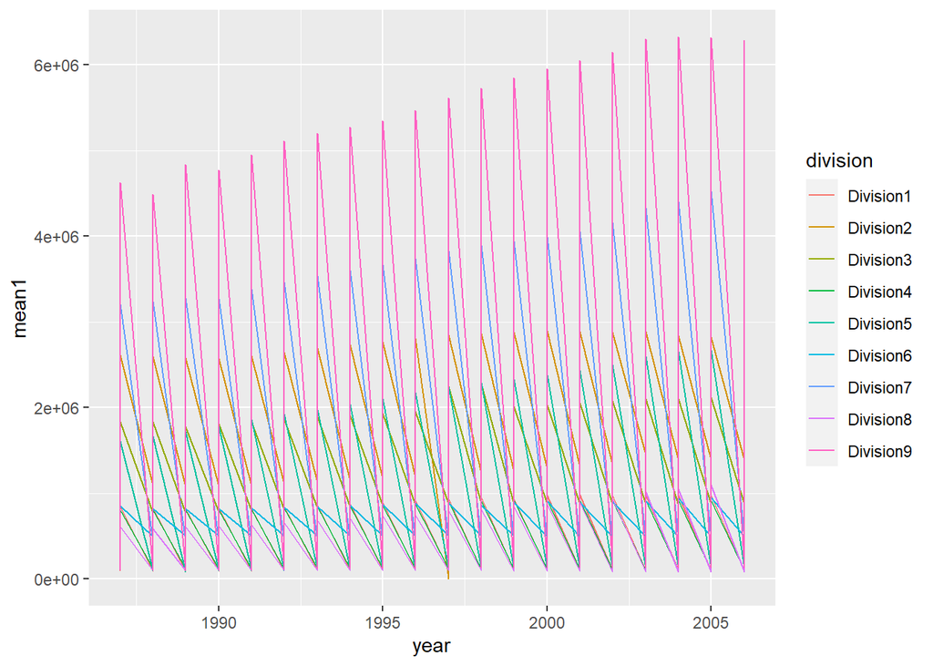

```r
plot.state(county_non_county_combine$non_county_combine)
```

## Plot function for county

For the class county we do a similar plotting function. This function allows the user firstly to specify the state of interest, giving a default value if not specified,

secondly determine whether the “top” or ‘bottom’ most counties should be looked at with a default for ‘top’

thirdly, instruct how many of the “top” or “bottom” will be investigated with a default value of 5

To achieve this we use chaining. First we input the data frame, subset the rows using the `filter()` function to get the state of interest,

Then we use `group_by()` and `summarize()` to group and further subset the data.

We arrange the data using an if/else statement to sort in descending or ascending order based on the specification “top” or “bottom”.

Lastly, we take the the specified amount using the `head()` function. Since the data is already sorted there is no need for the `tail()` function. `ggplot()` creates the plot.

```r
plot.county <- function(df2, state_of_interest = "NC", top_bottom = "top", amount_top_bottom = 5, var_name = "enrollment_value"){

  df2 %>% filter(county_state == state_of_interest) %>%
    group_by(get(var_name), area_name, year)%>%
  summarize(mean2 = mean(get(var_name)))%>%

  arrange(if (top_bottom == "top"){desc(mean2)} else{mean2})%>%

  head(amount_top_bottom)->new_df2


  ggplot(new_df2, aes(x = year, y = var_name, color = area_name)) +
geom_line()



}
```

### Plot for county

Here we produce the plot for county.

[figure not shown]

```r
plot.county(county_non_county_combine$county_combine)
```

# Conclusion and Putting it all together

The end of your report we do the following

## Running the data processing function on the two URLs

We run the data processing function on the two enrollment URLs given previously, by calling

```r
wrapper_call_1<-my_wrapper("https://www4.stat.ncsu.edu/~online/datasets/EDU01a.csv")

wrapper_call_1
```

```
## $CountyData
## # A tibble: 31,450 × 7
##    area_name   STCOU ends_with_D enrollment_value  year survey_type county_state
##    <chr>       <chr> <chr>                  <dbl> <dbl> <chr>       <chr>
##  1 Autauga, AL 01001 EDU010187D              6829  1987 EDU0101     AL
##  2 Autauga, AL 01001 EDU010188D              6900  1988 EDU0101     AL
##  3 Autauga, AL 01001 EDU010189D              6920  1989 EDU0101     AL
##  4 Autauga, AL 01001 EDU010190D              6847  1990 EDU0101     AL
##  5 Autauga, AL 01001 EDU010191D              7008  1991 EDU0101     AL
##  6 Autauga, AL 01001 EDU010192D              7137  1992 EDU0101     AL
##  7 Autauga, AL 01001 EDU010193D              7152  1993 EDU0101     AL
##  8 Autauga, AL 01001 EDU010194D              7381  1994 EDU0101     AL
##  9 Autauga, AL 01001 EDU010195D              7568  1995 EDU0101     AL
## 10 Autauga, AL 01001 EDU010196D              7834  1996 EDU0101     AL
## # … with 31,440 more rows
##
## $NonCountyData
## # A tibble: 530 × 7
##    area_name     STCOU ends_with_D enrollment_value  year survey_type division
##    <chr>         <chr> <chr>                  <dbl> <dbl> <chr>       <chr>
##  1 UNITED STATES 00000 EDU010187D          40024299  1987 EDU0101     ERROR
##  2 UNITED STATES 00000 EDU010188D          39967624  1988 EDU0101     ERROR
##  3 UNITED STATES 00000 EDU010189D          40317775  1989 EDU0101     ERROR
##  4 UNITED STATES 00000 EDU010190D          40737600  1990 EDU0101     ERROR
##  5 UNITED STATES 00000 EDU010191D          41385442  1991 EDU0101     ERROR
##  6 UNITED STATES 00000 EDU010192D          42088151  1992 EDU0101     ERROR
##  7 UNITED STATES 00000 EDU010193D          42724710  1993 EDU0101     ERROR
##  8 UNITED STATES 00000 EDU010194D          43369917  1994 EDU0101     ERROR
##  9 UNITED STATES 00000 EDU010195D          43993459  1995 EDU0101     ERROR
## 10 UNITED STATES 00000 EDU010196D          44715737  1996 EDU0101     ERROR
## # … with 520 more rows
```

```r
wrapper_call_2<-my_wrapper("https://www4.stat.ncsu.edu/~online/datasets/EDU01b.csv")

wrapper_call_2
```

```
## $CountyData
## # A tibble: 31,450 × 7
##    area_name   STCOU ends_with_D enrollment_value  year survey_type county_state
##    <chr>       <chr> <chr>                  <dbl> <dbl> <chr>       <chr>
##  1 Autauga, AL 01001 EDU010197D              8099  1997 EDU0101     AL
##  2 Autauga, AL 01001 EDU010198D              8211  1998 EDU0101     AL
##  3 Autauga, AL 01001 EDU010199D              8489  1999 EDU0101     AL
##  4 Autauga, AL 01001 EDU010200D              8912  2000 EDU0102     AL
##  5 Autauga, AL 01001 EDU010201D              8626  2001 EDU0102     AL
##  6 Autauga, AL 01001 EDU010202D              8762  2002 EDU0102     AL
##  7 Autauga, AL 01001 EDU015203D              9105  2003 EDU0152     AL
##  8 Autauga, AL 01001 EDU015204D              9200  2004 EDU0152     AL
##  9 Autauga, AL 01001 EDU015205D              9559  2005 EDU0152     AL
## 10 Autauga, AL 01001 EDU015206D              9652  2006 EDU0152     AL
## # … with 31,440 more rows
##
## $NonCountyData
## # A tibble: 530 × 7
##    area_name     STCOU ends_with_D enrollment_value  year survey_type division
##    <chr>         <chr> <chr>                  <dbl> <dbl> <chr>       <chr>
##  1 UNITED STATES 00000 EDU010197D          44534459  1997 EDU0101     ERROR
##  2 UNITED STATES 00000 EDU010198D          46245814  1998 EDU0101     ERROR
##  3 UNITED STATES 00000 EDU010199D          46368903  1999 EDU0101     ERROR
##  4 UNITED STATES 00000 EDU010200D          46818690  2000 EDU0102     ERROR
##  5 UNITED STATES 00000 EDU010201D          47127066  2001 EDU0102     ERROR
##  6 UNITED STATES 00000 EDU010202D          47606570  2002 EDU0102     ERROR
##  7 UNITED STATES 00000 EDU015203D          48506317  2003 EDU0152     ERROR
##  8 UNITED STATES 00000 EDU015204D          48693287  2004 EDU0152     ERROR
##  9 UNITED STATES 00000 EDU015205D          48978555  2005 EDU0152     ERROR
## 10 UNITED STATES 00000 EDU015206D          49140702  2006 EDU0152     ERROR
## # … with 520 more rows
```

## Running the data combining function on the two URLs

Next we run your data combining function to put these into one object (with two data frames)

```r
county_non_county_combine <- my_wrapper_combine(wrapper_call_1, wrapper_call_2)

county_non_county_combine
```

```
## $county_combine
## # A tibble: 62,900 × 7
##    area_name   STCOU ends_with_D enrollment_value  year survey_type county_state
##    <chr>       <chr> <chr>                  <dbl> <dbl> <chr>       <chr>
##  1 Autauga, AL 01001 EDU010187D              6829  1987 EDU0101     AL
##  2 Autauga, AL 01001 EDU010188D              6900  1988 EDU0101     AL
##  3 Autauga, AL 01001 EDU010189D              6920  1989 EDU0101     AL
##  4 Autauga, AL 01001 EDU010190D              6847  1990 EDU0101     AL
##  5 Autauga, AL 01001 EDU010191D              7008  1991 EDU0101     AL
##  6 Autauga, AL 01001 EDU010192D              7137  1992 EDU0101     AL
##  7 Autauga, AL 01001 EDU010193D              7152  1993 EDU0101     AL
##  8 Autauga, AL 01001 EDU010194D              7381  1994 EDU0101     AL
##  9 Autauga, AL 01001 EDU010195D              7568  1995 EDU0101     AL
## 10 Autauga, AL 01001 EDU010196D              7834  1996 EDU0101     AL
## # … with 62,890 more rows
##
## $non_county_combine
## # A tibble: 1,060 × 7
##    area_name     STCOU ends_with_D enrollment_value  year survey_type division
##    <chr>         <chr> <chr>                  <dbl> <dbl> <chr>       <chr>
##  1 UNITED STATES 00000 EDU010187D          40024299  1987 EDU0101     ERROR
##  2 UNITED STATES 00000 EDU010188D          39967624  1988 EDU0101     ERROR
##  3 UNITED STATES 00000 EDU010189D          40317775  1989 EDU0101     ERROR
##  4 UNITED STATES 00000 EDU010190D          40737600  1990 EDU0101     ERROR
##  5 UNITED STATES 00000 EDU010191D          41385442  1991 EDU0101     ERROR
##  6 UNITED STATES 00000 EDU010192D          42088151  1992 EDU0101     ERROR
##  7 UNITED STATES 00000 EDU010193D          42724710  1993 EDU0101     ERROR
##  8 UNITED STATES 00000 EDU010194D          43369917  1994 EDU0101     ERROR
##  9 UNITED STATES 00000 EDU010195D          43993459  1995 EDU0101     ERROR
## 10 UNITED STATES 00000 EDU010196D          44715737  1996 EDU0101     ERROR
## # … with 1,050 more rows
```

### Plot function on state data frame

We now proceed to use the plot function on the state data frame to produce the following plot.

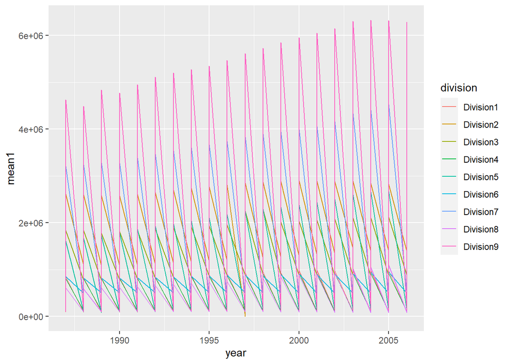

```r
plot.state(county_non_county_combine$non_county_combine)
```

### Plot function on the county data frame

Additionally, we use the plot function on the county data frame

[figure not shown]

```r
plot.county(county_non_county_combine$county_combine, "PA", "top", 7)
```

[figure not shown]

```r
plot.county(county_non_county_combine$county_combine, "PA", "bottom", 4)
```

#### without specifying anything (defaults used)

[figure not shown]

```r
plot.county(county_non_county_combine$county_combine)
```

[figure not shown]

```r
plot.county(county_non_county_combine$county_combine, "MN", "top", 10)
```

## Runing data procession function on four new data sets

Lastly, we’ll read in another similar data set and apply our functions.

We first run the data processing function on the four following data sets which we shall denote as first, second, third and fourth from hence forth.

```r
wrapper_call_new_1<-my_wrapper("https://www4.stat.ncsu.edu/~online/datasets/PST01a.csv")


wrapper_call_new_2<-my_wrapper("https://www4.stat.ncsu.edu/~online/datasets/PST01b.csv")


wrapper_call_new_3<-my_wrapper("https://www4.stat.ncsu.edu/~online/datasets/PST01c.csv")


wrapper_call_new_4<-my_wrapper("https://www4.stat.ncsu.edu/~online/datasets/PST01d.csv")
```

## Running the combine function on three pairs of the new data

We now run the data combining function three times on the following pairs of the four data sets (first, second), (first, third), (first, fourth). To be more specific, first and second inputs “wrapper_call_new_1” and “wrapper_call_new_2”, first and third inputs “wrapper_call_new_1” and “wrapper_call_new_3” and first and fourth inputs “wrapper_call_new_1” and “wrapper_call_new_4”

We save as objects “county_non_county_combine_1_2”, “county_non_county_combine_1_3” and “county_non_county_combine_1_4” respectively.

### First and second

```r
my_wrapper_combine(wrapper_call_new_1, wrapper_call_new_2)
```

```
## $county_combine
## # A tibble: 62,900 × 7
##    area_name   STCOU ends_with_D enrollment_value  year survey_type county_state
##    <chr>       <chr> <chr>                  <dbl> <dbl> <chr>       <chr>
##  1 Autauga, AL 01001 PST015171D             25508  1971 PST0151     AL
##  2 Autauga, AL 01001 PST015172D             27166  1972 PST0151     AL
##  3 Autauga, AL 01001 PST015173D             28463  1973 PST0151     AL
##  4 Autauga, AL 01001 PST015174D             29266  1974 PST0151     AL
##  5 Autauga, AL 01001 PST015175D             29718  1975 PST0151     AL
##  6 Autauga, AL 01001 PST015176D             29896  1976 PST0151     AL
##  7 Autauga, AL 01001 PST015177D             30462  1977 PST0151     AL
##  8 Autauga, AL 01001 PST015178D             30882  1978 PST0151     AL
##  9 Autauga, AL 01001 PST015179D             32055  1979 PST0151     AL
## 10 Autauga, AL 01001 PST025181D             31985  1981 PST0251     AL
## # … with 62,890 more rows
##
## $non_county_combine
## # A tibble: 1,060 × 7
##    area_name     STCOU ends_with_D enrollment_value  year survey_type division
##    <chr>         <chr> <chr>                  <dbl> <dbl> <chr>       <chr>
##  1 UNITED STATES 00000 PST015171D         206827028  1971 PST0151     ERROR
##  2 UNITED STATES 00000 PST015172D         209283904  1972 PST0151     ERROR
##  3 UNITED STATES 00000 PST015173D         211357490  1973 PST0151     ERROR
##  4 UNITED STATES 00000 PST015174D         213341552  1974 PST0151     ERROR
##  5 UNITED STATES 00000 PST015175D         215465246  1975 PST0151     ERROR
##  6 UNITED STATES 00000 PST015176D         217562728  1976 PST0151     ERROR
##  7 UNITED STATES 00000 PST015177D         219759860  1977 PST0151     ERROR
##  8 UNITED STATES 00000 PST015178D         222095080  1978 PST0151     ERROR
##  9 UNITED STATES 00000 PST015179D         224567234  1979 PST0151     ERROR
## 10 UNITED STATES 00000 PST025181D         229466391  1981 PST0251     ERROR
## # … with 1,050 more rows
```

```r
county_non_county_combine_1_2 <- my_wrapper_combine(wrapper_call_new_1, wrapper_call_new_2)
```

### First and third

```r
my_wrapper_combine(wrapper_call_new_1, wrapper_call_new_3)
```

```
## $county_combine
## # A tibble: 62,900 × 7
##    area_name   STCOU ends_with_D enrollment_value  year survey_type county_state
##    <chr>       <chr> <chr>                  <dbl> <dbl> <chr>       <chr>
##  1 Autauga, AL 01001 PST015171D             25508  1971 PST0151     AL
##  2 Autauga, AL 01001 PST015172D             27166  1972 PST0151     AL
##  3 Autauga, AL 01001 PST015173D             28463  1973 PST0151     AL
##  4 Autauga, AL 01001 PST015174D             29266  1974 PST0151     AL
##  5 Autauga, AL 01001 PST015175D             29718  1975 PST0151     AL
##  6 Autauga, AL 01001 PST015176D             29896  1976 PST0151     AL
##  7 Autauga, AL 01001 PST015177D             30462  1977 PST0151     AL
##  8 Autauga, AL 01001 PST015178D             30882  1978 PST0151     AL
##  9 Autauga, AL 01001 PST015179D             32055  1979 PST0151     AL
## 10 Autauga, AL 01001 PST025181D             31985  1981 PST0251     AL
## # … with 62,890 more rows
##
## $non_county_combine
## # A tibble: 1,060 × 7
##    area_name     STCOU ends_with_D enrollment_value  year survey_type division
##    <chr>         <chr> <chr>                  <dbl> <dbl> <chr>       <chr>
##  1 UNITED STATES 00000 PST015171D         206827028  1971 PST0151     ERROR
##  2 UNITED STATES 00000 PST015172D         209283904  1972 PST0151     ERROR
##  3 UNITED STATES 00000 PST015173D         211357490  1973 PST0151     ERROR
##  4 UNITED STATES 00000 PST015174D         213341552  1974 PST0151     ERROR
##  5 UNITED STATES 00000 PST015175D         215465246  1975 PST0151     ERROR
##  6 UNITED STATES 00000 PST015176D         217562728  1976 PST0151     ERROR
##  7 UNITED STATES 00000 PST015177D         219759860  1977 PST0151     ERROR
##  8 UNITED STATES 00000 PST015178D         222095080  1978 PST0151     ERROR
##  9 UNITED STATES 00000 PST015179D         224567234  1979 PST0151     ERROR
## 10 UNITED STATES 00000 PST025181D         229466391  1981 PST0251     ERROR
## # … with 1,050 more rows
```

```r
county_non_county_combine_1_3 <- my_wrapper_combine(wrapper_call_new_1, wrapper_call_new_3)
```

### First and fourth

```r
my_wrapper_combine(wrapper_call_new_1, wrapper_call_new_4)
```

```
## $county_combine
## # A tibble: 62,900 × 7
##    area_name   STCOU ends_with_D enrollment_value  year survey_type county_state
##    <chr>       <chr> <chr>                  <dbl> <dbl> <chr>       <chr>
##  1 Autauga, AL 01001 PST015171D             25508  1971 PST0151     AL
##  2 Autauga, AL 01001 PST015172D             27166  1972 PST0151     AL
##  3 Autauga, AL 01001 PST015173D             28463  1973 PST0151     AL
##  4 Autauga, AL 01001 PST015174D             29266  1974 PST0151     AL
##  5 Autauga, AL 01001 PST015175D             29718  1975 PST0151     AL
##  6 Autauga, AL 01001 PST015176D             29896  1976 PST0151     AL
##  7 Autauga, AL 01001 PST015177D             30462  1977 PST0151     AL
##  8 Autauga, AL 01001 PST015178D             30882  1978 PST0151     AL
##  9 Autauga, AL 01001 PST015179D             32055  1979 PST0151     AL
## 10 Autauga, AL 01001 PST025181D             31985  1981 PST0251     AL
## # … with 62,890 more rows
##
## $non_county_combine
## # A tibble: 1,060 × 7
##    area_name     STCOU ends_with_D enrollment_value  year survey_type division
##    <chr>         <chr> <chr>                  <dbl> <dbl> <chr>       <chr>
##  1 UNITED STATES 00000 PST015171D         206827028  1971 PST0151     ERROR
##  2 UNITED STATES 00000 PST015172D         209283904  1972 PST0151     ERROR
##  3 UNITED STATES 00000 PST015173D         211357490  1973 PST0151     ERROR
##  4 UNITED STATES 00000 PST015174D         213341552  1974 PST0151     ERROR
##  5 UNITED STATES 00000 PST015175D         215465246  1975 PST0151     ERROR
##  6 UNITED STATES 00000 PST015176D         217562728  1976 PST0151     ERROR
##  7 UNITED STATES 00000 PST015177D         219759860  1977 PST0151     ERROR
##  8 UNITED STATES 00000 PST015178D         222095080  1978 PST0151     ERROR
##  9 UNITED STATES 00000 PST015179D         224567234  1979 PST0151     ERROR
## 10 UNITED STATES 00000 PST025181D         229466391  1981 PST0251     ERROR
## # … with 1,050 more rows
```

```r
county_non_county_combine_1_4 <- my_wrapper_combine(wrapper_call_new_1, wrapper_call_new_4)
```

### State data frame

We now run the plot function for the state data frame for each

#### Plot for First and second

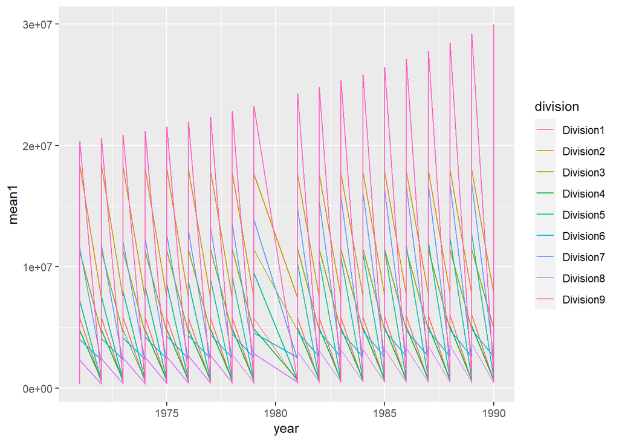

```r
plot.state(county_non_county_combine_1_2$non_county_combine)
```

#### Plot for First and third

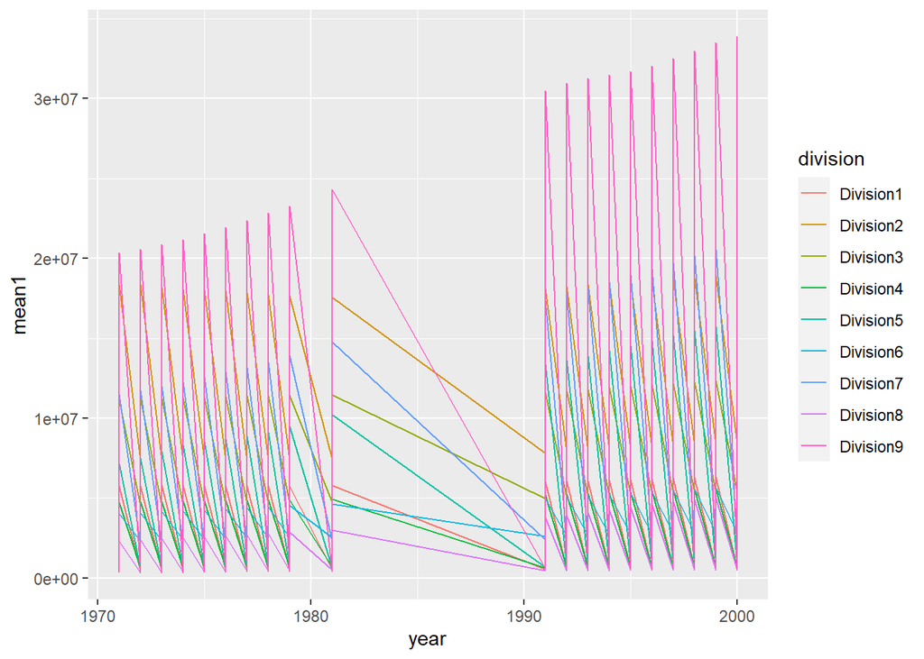

```r
plot.state(county_non_county_combine_1_3$non_county_combine)
```

#### Plot for First and fourth

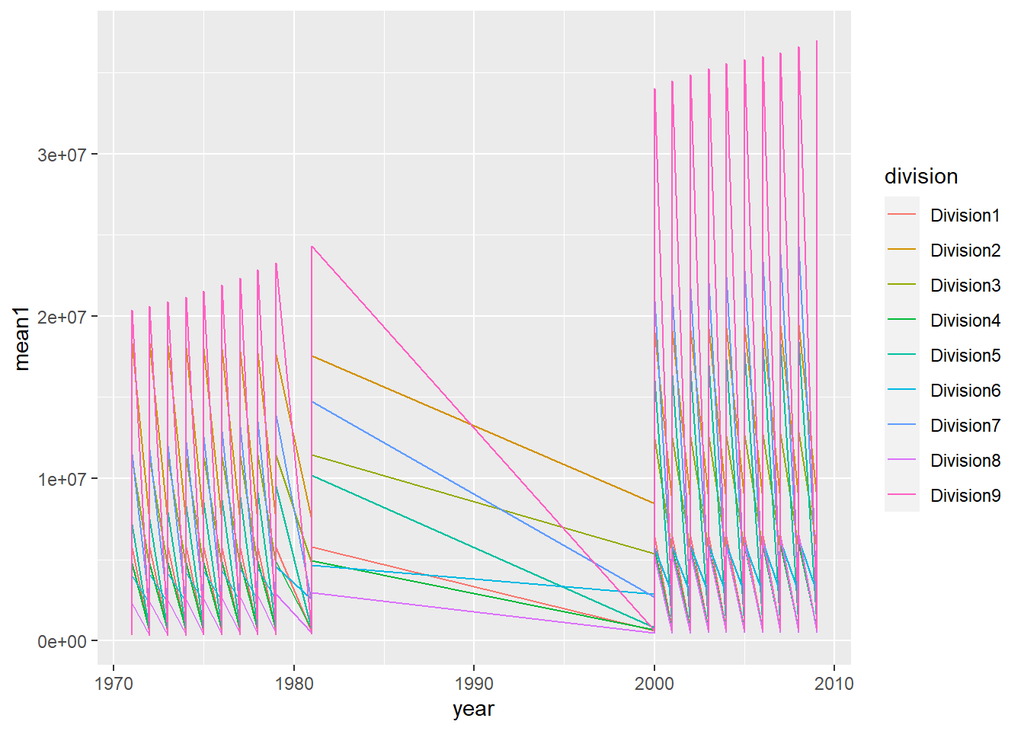

```r
plot.state(county_non_county_combine_1_4$non_county_combine)
```

### County data frame

We now use the plot function for the county data frame.

#### First and second

##### specifying the state to be “CT”, the group being the top, the number looked at being 6

[figure not shown]

```r
plot.county(county_non_county_combine_1_2$county_combine, "CT", "top", 6)
```

##### specifying the state to be “NC”, the group being the bottom, the number looked at being 10

[figure not shown]

```r
plot.county(county_non_county_combine_1_2$county_combine, "NC", "bottom", 10)
```

##### without specifying anything (defaults used)

[figure not shown]

```r
plot.county(county_non_county_combine_1_2$county_combine)
```

##### specifying the state to be “MN”, the group being the top, the number looked at being 4

[figure not shown]

```r
plot.county(county_non_county_combine_1_2$county_combine, "MN", "top", 4)
```

#### First and third

we repeat for first and third

##### specifying the state to be “CT”, the group being the top, the number looked at being 6

[figure not shown]

```r
plot.county(county_non_county_combine_1_3$county_combine, "CT", "top", 6)
```

##### specifying the state to be “NC”, the group being the bottom, the number looked at being 10

[figure not shown]

```r
plot.county(county_non_county_combine_1_3$county_combine, "NC", "bottom", 10)
```

##### without specifying anything (defaults used)

[figure not shown]

```r
plot.county(county_non_county_combine_1_3$county_combine)
```

##### specifying the state to be “MN”, the group being the top, the number looked at being 4

[figure not shown]

```r
plot.county(county_non_county_combine_1_3$county_combine, "MN", "top", 4)
```

#### First and fourth

we repeat for first and fourth

##### specifying the state to be “CT”, the group being the top, the number looked at being 6

[figure not shown]

```r
plot.county(county_non_county_combine_1_4$county_combine, "CT", "top", 6)
```

##### specifying the state to be “NC”, the group being the bottom, the number looked at being 10

[figure not shown]

```r
plot.county(county_non_county_combine_1_4$county_combine, "NC", "bottom", 10)
```

##### without specifying anything (defaults used)

[figure not shown]

```r
plot.county(county_non_county_combine_1_4$county_combine)
```

##### specifying the state to be “MN”, the group being the top, the number looked at being 4

[figure not shown]

```r
plot.county(county_non_county_combine_1_4$county_combine, "MN", "top", 4)
```